# 高维基因数据分析

杨帆

2021-05-07

# 正态性检验

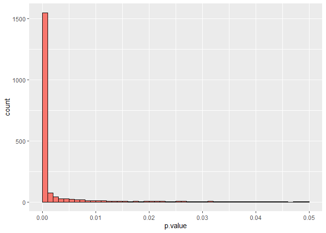

有1912个变量在$\alpha=0.05$水准下拒绝原假设，可认为不服从正态分布（尽管存在大量的假阳性）

## box-cox数据转换

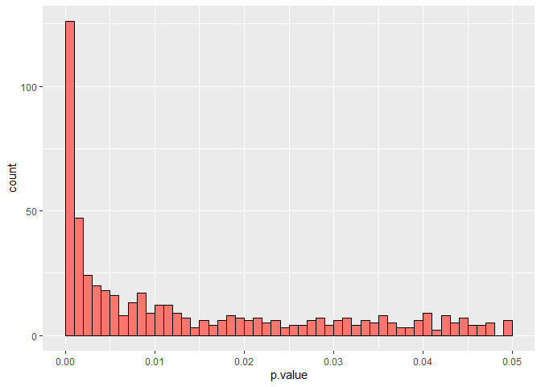

经过Box-cox转换，依然有527个基因不服从正态分布。

故这里使用原数据采用Wilcoxon检验2000个基因在正常组织和肿瘤组织的分布是否相同。

# Supervised screening

采用Wilcoxon检验比较正常组织和肿瘤组织基因表达均值的差异

top 200基因p值的分布

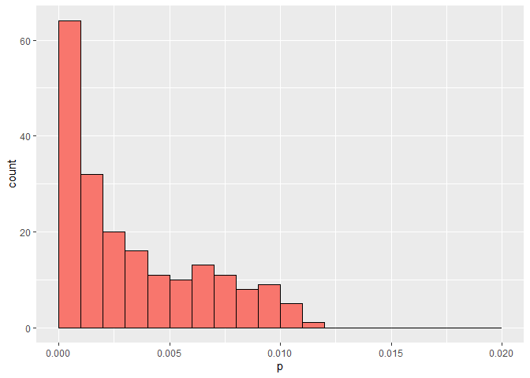

top 200基因wilcoxon检验结果如下

| .y. | group1 | group2 | n1 | n2 | statistic | p |
| --- | --- | --- | --- | --- | --- | --- |
| Has493 | 0 | 1 | 22 | 40 | 778 | 0.000 |
| Has1772 | 0 | 1 | 22 | 40 | 110 | 0.000 |
| Has513 | 0 | 1 | 22 | 40 | 119 | 0.000 |
| Has1042 | 0 | 1 | 22 | 40 | 119 | 0.000 |
| Has1671 | 0 | 1 | 22 | 40 | 129 | 0.000 |
| Has780 | 0 | 1 | 22 | 40 | 140 | 0.000 |
| Has1582 | 0 | 1 | 22 | 40 | 145 | 0.000 |
| Has625 | 0 | 1 | 22 | 40 | 150 | 0.000 |
| Has377 | 0 | 1 | 22 | 40 | 729 | 0.000 |
| Has1423 | 0 | 1 | 22 | 40 | 727 | 0.000 |
| Has1060 | 0 | 1 | 22 | 40 | 155 | 0.000 |
| Has897 | 0 | 1 | 22 | 40 | 723 | 0.000 |
| Has249 | 0 | 1 | 22 | 40 | 722 | 0.000 |
| Has1771 | 0 | 1 | 22 | 40 | 147 | 0.000 |
| Has765 | 0 | 1 | 22 | 40 | 716 | 0.000 |
| Has1635 | 0 | 1 | 22 | 40 | 715 | 0.000 |
| Has964 | 0 | 1 | 22 | 40 | 166 | 0.000 |
| Has365 | 0 | 1 | 22 | 40 | 167 | 0.000 |
| Has245 | 0 | 1 | 22 | 40 | 710 | 0.000 |
| Has1325 | 0 | 1 | 22 | 40 | 171 | 0.000 |
| Has138 | 0 | 1 | 22 | 40 | 174 | 0.000 |
| Has399 | 0 | 1 | 22 | 40 | 174 | 0.000 |
| Has1153 | 0 | 1 | 22 | 40 | 177 | 0.000 |
| Has66 | 0 | 1 | 22 | 40 | 702 | 0.000 |
| Has1002 | 0 | 1 | 22 | 40 | 182 | 0.000 |
| Has1730 | 0 | 1 | 22 | 40 | 182 | 0.000 |
| Has267 | 0 | 1 | 22 | 40 | 697 | 0.000 |
| Has391 | 0 | 1 | 22 | 40 | 186 | 0.000 |
| Has1843 | 0 | 1 | 22 | 40 | 693 | 0.000 |
| Has75 | 0 | 1 | 22 | 40 | 189 | 0.000 |

[output cut: 170 more lines]

# 拟合logistic回归，使用lasso、MCP、L0penalty进行变量选择

## lasso

lasso解的路径

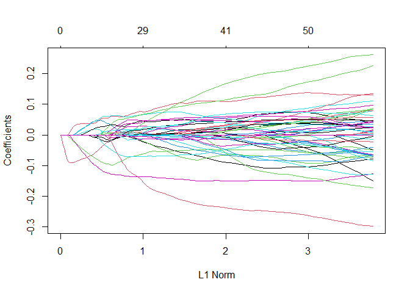

交叉验证结果

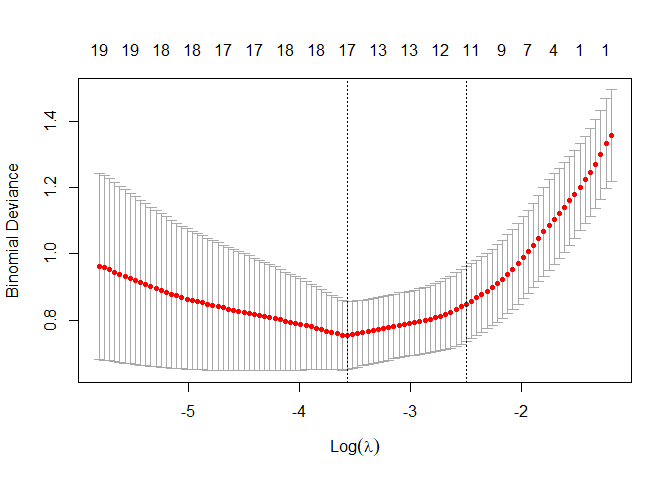

经过5折交叉验证，选取$\lambda =0.028$，拟合模型，选取基因如下：

| gene_names | beta |
| --- | --- |
| Has1772 | 0.0590604 |
| Has1582 | 0.0087494 |
| Has377 | -0.1310686 |
| Has1423 | -0.0072101 |
| Has765 | -0.0855988 |
| Has1325 | 0.0164808 |
| Has66 | -0.0062898 |
| Has391 | 0.0104141 |
| Has1346 | 0.0286785 |
| Has1870 | 0.0609615 |
| Has286 | -0.0058864 |
| Has1993 | 0.0076547 |
| Has1058 | -0.0069159 |
| Has590 | 0.0067017 |
| Has1221 | 0.0363005 |
| Has1546 | 0.0165767 |
| Has627 | 0.0028863 |
| Has617 | -0.0655481 |
| Has14 | -0.0806999 |
| Has527 | 0.0491895 |
| Has271 | 0.0063297 |
| Has427 | 0.0305240 |

## MCP

MCP解的路径

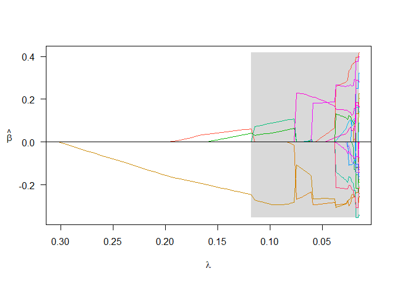

交叉验证结果

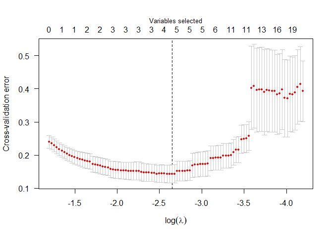

经过5折交叉验证，选取$\lambda =0.07$，拟合模型，选取基因如下：

| gene_names | beta |
| --- | --- |
| Has377 | -0.2582221 |
| Has249 | -0.1220857 |
| Has1353 | 0.2262149 |

## L_0 penalization

采用AIC、BIC逐步回归进行变量选择，结果如下

- AIC变量选择结果

| gene_names | beta |
| --- | --- |
| Has493 | -23.4524606 |
| Has1772 | 2.5626000 |
| Has513 | 51.9226871 |
| Has1042 | -16.4054371 |
| Has1671 | -7.2031249 |
| Has780 | -2.2076863 |
| Has1582 | 2.3624980 |
| Has625 | 20.6616263 |
| Has377 | 4.4575177 |
| Has1423 | 39.1534485 |
| Has1060 | -31.2035218 |
| Has897 | -11.9351365 |
| Has249 | 18.7636932 |
| Has1771 | -14.4371977 |
| Has765 | -14.2721990 |
| Has1635 | 4.4134226 |
| Has964 | -1.7867281 |
| Has365 | 12.1322260 |
| Has245 | -0.1093456 |
| Has1325 | 10.2460257 |
| Has138 | -14.0203866 |
| Has399 | 44.3246534 |
| Has1153 | 5.6620645 |
| Has66 | 1.3977166 |
| Has1002 | -1.9796728 |
| Has1730 | -24.2019997 |
| Has267 | -2.8971224 |
| Has391 | -19.5188879 |
| Has1843 | -9.9146218 |
| Has75 | -16.3976221 |
| Has822 | -21.8310523 |
| Has1411 | -3.5186230 |
| Has1414 | -0.1901127 |
| Has992 | 14.1177360 |
| Has1494 | 18.5064697 |
| Has1900 | 19.5099934 |
| Has43 | 20.3267902 |
| Has241 | 9.1756826 |
| Has1346 | -0.9559092 |
| Has1648 | 13.5462993 |
| Has31 | -0.5647243 |
| Has571 | -24.9221297 |
| Has1770 | 18.8374908 |
| Has26 | -17.0912478 |
| Has187 | -9.8426235 |
| Has1406 | -21.7059606 |
| Has1808 | -8.3528828 |
| Has47 | 8.8028657 |
| Has698 | -3.1211062 |
| Has127 | 7.3279526 |
| Has802 | 36.7823911 |
| Has1293 | -26.2402958 |
| Has62 | -7.3583562 |
| Has467 | -13.3681638 |
| Has1263 | 20.4009508 |
| Has1634 | -8.4565375 |
| Has1679 | -3.6724988 |
| Has1870 | 8.7691586 |
| Has1067 | -24.4444919 |
| Has619 | -4.3894406 |
| Has1473 | -7.4072015 |

- BIC变量选择结果

| gene_names | beta |
| --- | --- |
| Has493 | -23.4524606 |
| Has1772 | 2.5626000 |
| Has513 | 51.9226871 |
| Has1042 | -16.4054371 |
| Has1671 | -7.2031249 |
| Has780 | -2.2076863 |
| Has1582 | 2.3624980 |
| Has625 | 20.6616263 |
| Has377 | 4.4575177 |
| Has1423 | 39.1534485 |
| Has1060 | -31.2035218 |
| Has897 | -11.9351365 |
| Has249 | 18.7636932 |
| Has1771 | -14.4371977 |
| Has765 | -14.2721990 |
| Has1635 | 4.4134226 |
| Has964 | -1.7867281 |
| Has365 | 12.1322260 |
| Has245 | -0.1093456 |
| Has1325 | 10.2460257 |
| Has138 | -14.0203866 |
| Has399 | 44.3246534 |
| Has1153 | 5.6620645 |
| Has66 | 1.3977166 |
| Has1002 | -1.9796728 |
| Has1730 | -24.2019997 |
| Has267 | -2.8971224 |
| Has391 | -19.5188879 |
| Has1843 | -9.9146218 |
| Has75 | -16.3976221 |
| Has822 | -21.8310523 |
| Has1411 | -3.5186230 |
| Has1414 | -0.1901127 |
| Has992 | 14.1177360 |
| Has1494 | 18.5064697 |
| Has1900 | 19.5099934 |
| Has43 | 20.3267902 |
| Has241 | 9.1756826 |
| Has1346 | -0.9559092 |
| Has1648 | 13.5462993 |
| Has31 | -0.5647243 |
| Has571 | -24.9221297 |
| Has1770 | 18.8374908 |
| Has26 | -17.0912478 |
| Has187 | -9.8426235 |
| Has1406 | -21.7059606 |
| Has1808 | -8.3528828 |
| Has47 | 8.8028657 |
| Has698 | -3.1211062 |
| Has127 | 7.3279526 |
| Has802 | 36.7823911 |
| Has1293 | -26.2402958 |
| Has62 | -7.3583562 |
| Has467 | -13.3681638 |
| Has1263 | 20.4009508 |
| Has1634 | -8.4565375 |
| Has1679 | -3.6724988 |
| Has1870 | 8.7691586 |
| Has1067 | -24.4444919 |
| Has619 | -4.3894406 |
| Has1473 | -7.4072015 |

可以看到$L_0$惩罚筛选变量效果并不好，选取的变量与样本量基本一致($\#(选的变量个数)+截距项=样本量$)。

# K means聚类

可视化结果，可以看到很多类有重合。

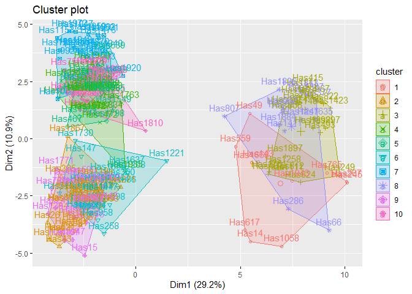

kmeans聚类结果

| gene_names | genes |
| --- | --- |
| 1 | Has765 , Has245 , Has267 , Has143 , Has1058, Has1668, Has617 , Has559 , Has14 , Has1943, Has49 |
| 2 | Has1772, Has365 , Has43 , Has31 , Has571 , Has26 , Has187 , Has127 , Has62 , Has1067, Has619 , Has1227, Has1993, Has994 , Has141 , Has1867, Has1110, Has1546, Has444 , Has1334, Has86 , Has163 , Has199 … |
| 3 | Has493 , Has1423, Has897 , Has249 , Has822 , Has1494, Has739 , Has415 , Has1967, Has824 , Has111 , Has1674, Has201 , Has1974, Has1897, Has812 , Has1111, Has1258, Has437 , Has806 , Has1892, Has1761 |
| 4 | Has625 , Has391 , Has1406, Has802 , Has1679, Has1372, Has1511, Has830 , Has1260, Has1675, Has1115, Has1935, Has102 , Has1965, Has1583, Has1960, Has1763, Has834 , Has527 , Has1472, Has1136, Has1073, Ha… |
| 5 | Has1900, Has1770, Has467 , Has1549, Has495 , Has1256, Has989 , Has1904, Has100 , Has1799, Has639 , Has1168, Has190 , Has882 , Has1887, Has85 , Has785 , Has1798 |
| 6 | Has513 , Has1730, Has1648, Has1808, Has698 , Has1263, Has652 , Has1208, Has258 , Has1221, Has1187, Has360 , Has147 , Has440 , Has264 , Has1912, Has1942, Has1489, Has1637, Has1447, Has1886, Has694 , Ha… |
| 7 | Has1153, Has1002, Has992 , Has1293, Has1634, Has1870, Has1473, Has1983, Has581 , Has1972, Has1047, Has1959, Has1340, Has601 , Has779 , Has1902, Has1196, Has648 , Has1248, Has549 , Has1920 |
| 8 | Has377 , Has1635, Has66 , Has1843, Has1411, Has286 , Has1387, Has1884, Has67 , Has1836, Has807 , Has1247, Has662 |
| 9 | Has1042, Has1671, Has780 , Has1060, Has1771, Has138 , Has399 , Has241 , Has1346, Has47 , Has72 , Has515 , Has590 , Has107 , Has1466, Has1442, Has15 , Has384 , Has500 , Has427 |
| 10 | Has1582, Has964 , Has1325, Has75 , Has1414, Has83 , Has295 , Has281 , Has520 , Has343 , Has529 , Has489 , Has1810, Has627 , Has1839, Has661 , Has1366, Has979 , Has1353, Has1534 |

# Composite penalization

这里采用了两种方法，分别是group lasso，group MCP。

## group lasso

group lasso解的路径

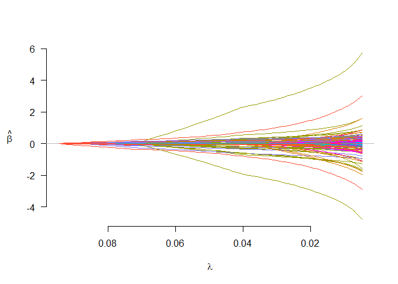

采用5折交叉验证的方法选择$\lambda$.

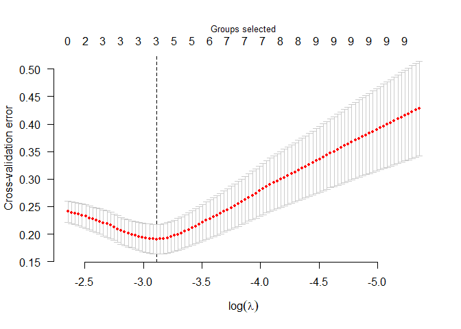

group lasso通过5折交叉验证选择$\lambda=0.044$，进行模型拟合，从200个基因中选出了23个变量,分别为：

| gene_names | beta |
| --- | --- |
| Has267 | 0.6092363 |
| Has1411 | 0.1876647 |
| Has1494 | 0.4618321 |
| Has286 | 0.0020350 |
| Has739 | 0.2321242 |
| Has415 | 0.1389012 |
| Has1058 | 0.0045176 |
| Has824 | 1.9657277 |
| Has111 | 0.2619316 |
| Has1387 | 0.1891688 |
| Has1674 | 0.1099478 |
| Has1884 | 0.1217743 |
| Has201 | 0.2878553 |
| Has1974 | 0.2840208 |
| Has67 | 0.1848672 |
| Has1111 | 0.2611245 |
| Has807 | 0.0050405 |
| Has1247 | 0.0648507 |
| Has1892 | 0.0406205 |
| Has1761 | 0.2142693 |
| Has559 | 0.1724631 |
| Has14 | 0.0134979 |
| Has662 | 0.2773290 |

回归系数均为正数，表明这23个基因在肿瘤组织表达更多，即其表达可能会促进肿瘤的生长。

## group MCP

group MCP解的路径

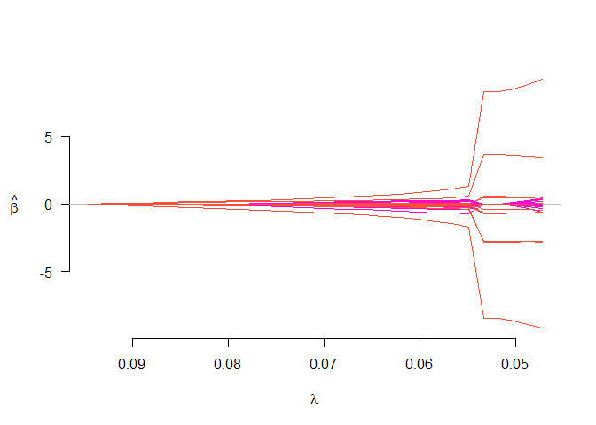

使用AIC准则选取$\lambda$，不同$\lambda$对应的AIC的值，选择使得AIC最小的$\lambda$进行模型拟合。

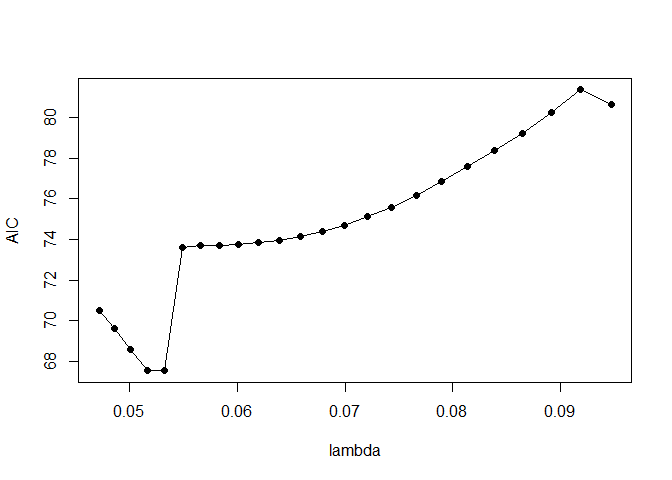

使得AIC最小的$\lambda=0.0517$，进行模型拟合，从200个基因中选出了4个变量，分别为：

| gene_names | beta |
| --- | --- |
| Has267 | 8.2821856 |
| Has1058 | 0.4559008 |
| Has617 | 0.6040329 |
| Has559 | 3.6396772 |

从表中可以看到，回归系数都是正的，表明这四个基因在肿瘤组织表达更多，即其表达可能会促进肿瘤的生长。

# lasso、MCP、L_0 penalt、group lasso和group MCP结果总结

- 以上5种方法选出的基因没有重合；
- lasso、MCP、group lasso和group MCP选出的基因也没有重合。
- lasso和MCP选出了一个共同的基因，结果如下：

| gene_names | lasso | MCP |
| --- | --- | --- |
| Has377 | -0.1310686 | -0.2582221 |

回归系数为负值，表明肿瘤组织中该基因表达较少。

- group lasso和group MCP方法均选出了Has267、Has1058、Has559三个基因，结果如下:

| gene_names | group_lasso | group_MCP |
| --- | --- | --- |
| Has267 | 0.6092363 | 8.2821856 |
| Has1058 | 0.0045176 | 0.4559008 |
| Has559 | 0.1724631 | 3.6396772 |

基因系数差异较大，但系数都为正，表明这三个基因在肿瘤组织表达更多，即其表达可能会促进肿瘤的生长。

- lasso、group lasso和group MCP选出的基因中有一个相同的。

| gene_names | lasso | group_lasso | group_MCP |
| --- | --- | --- | --- |
| Has1058 | -0.0069159 | 0.0045176 | 0.4559008 |

可以看到回归系数不同，但lasso、group lasso的系数都很小，接近0，group MCP回归系数稍大，专业结论慎下。